# Bike Sharing Case Study

Logan

2024-08-14

# Bike Sharing Case Study

This project was performed as a capstone to my Google Coursera Data Analytics Professional Certificate. The data was sourced from a fictional rideshare company, produce by Coursera and hosted by AWS. I focused on the time period of the last year, August 2023 to July 2024

[Click here for the data directory.](https://divvy-tripdata.s3.amazonaws.com/index.html)

### Key Objectives

1. Organize a useful portion of data out of a large data set.
2. Clean the data to make create easy to work with tables.
3. Answer key business question: How do annual members and casual riders use Cyclistic bikes differently?

Hypothesis: Targeted marketing campaigns toward the casual users of the ride sharing program could increase membership subscriptions and increase satisfaction with the service overall.

We’ll explore what changes could be made to current promotional marketing to target this demographic specifically.

## Environment

```r
library(tidyverse)
library(rio)
library(data.table)
library(knitr)
library(ggplot2)
```

## Data Processing

This project had a large number of .csv files mapped to different years. I started by unzipping all of the .csv files in my project directory, and then contemplated how best to gather all of them into a single data frame to work with. After searching for solutions online, I found this function through the rio package, which aggregates all of the contained files into one large data. The resulting dataset had over 5.7 million rows.

```r
my_data <- import_list(dir("C:\\Users\\miste\\Documents\\bike_case_study\\202404-divvy-tripdata\\", pattern=".csv"), rbind=TRUE)
my_data
```

Because this is such a large dataset, I need to verify that it contains all of the data we started with.

```r
range(my_data$started_at)
```

```
## [1] "2023-08-01 00:00:06 UTC" "2024-07-31 23:56:29 UTC"
```

Since this returns dates from August 2023 to July 2024, we know we’re on the right track. But I want to make sure it has sampled every month, so we’ll run another check.

```r
check_months <- data.frame(month(my_data$started_at))
unique(check_months)
```

|  | month.my_data.started_at. |
| --- | --- |
| 1 | 8 |
| 771694 | 9 |
| 1438065 | 10 |
| 1975178 | 11 |
| 2337696 | 12 |
| 2561769 | 1 |
| 2706642 | 2 |
| 2929806 | 3 |
| 3231493 | 4 |
| 3646518 | 5 |

[output cut: 2 more lines]

This creates a new data frame called “check_months” which is just made up of the value of the month for every ride in the original dataset. This is because the unique() function requires a data frame to work with. When we run unique(check_months) we see that every month is represented in the data set, so our import of all the data was successful.

Next, we want to get an idea of how this sample of rides tracks by members and by casual riders.

```r
table(my_data$member_casual)
```

```
##
##  casual  member
## 2038574 3677119
```

This displays an output which shows us exactly how many rides were taken by each class of user. I want to consider how the use behavior of casual riders and member riders differ, so we’ll run some analysis.

**Analysis:** If we figure out the habits of the casual riders, we may be able to target marketing promotions to earn them as subscribed members.

```r
bike_trips <- my_data %>%
  mutate(started_at = as_datetime(started_at)) %>%
  mutate(ended_at = as_datetime(ended_at)) %>%
  mutate(tripduration = ended_at - started_at) %>%
  mutate(weekend = ifelse(wday(started_at) %in% c(1,7), "weekend", "weekday"))
```

This code explores 2 avenues of user behavior. It takes the original my_data import and adds two new columns, **tripduration** and **weekend**.

The **trip duration** uses the recorded data of when the trip started and when the trip ended and creates a new entry of how long that trip lasted in seconds.

**Weekend** is a category that determines whether the day of the week that the user took the ride was a weekend or a weekday.

Now that we have the data sorted into useful categories, we can explore it. Before we do that, I want to sort the dataset based on the member column, so we can break down these statistics for each member class.

```r
split_list <- split(bike_trips, bike_trips$member_casual)
member_trips <- split_list$member #creates a new data frame for members only
casual_trips <- split_list$casual #creates a new data frame for casual riders
```

Next, we’ll see a simple graphic that breaks down the user habits based on the number of rides taken by day and member type.

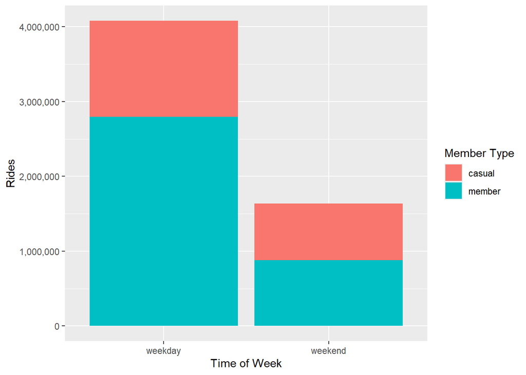

```r
ggplot(bike_trips)+geom_bar(mapping=aes(x=weekend, fill=member_casual))+
  labs(x="Time of Week", y="Rides")+
  guides(fill=guide_legend(title="Member Type"))+
  scale_y_continuous(labels = scales::comma)
```

Now we can perform some functions to delineate the behavior of the two user classes.

```r
# Comparing trip durations
mean(member_trips$tripduration) # 778.9345
```

```
## Time difference of 778.9345 secs
```

```r
mean(casual_trips$tripduration) # 1628.813
```

```
## Time difference of 1628.813 secs
```

```r
# We see that casual riders have an average trip duration twice as long members.
table(member_trips$weekend) # weekday - 2,797,347; weekend - 879,772
```

```
##
## weekday weekend
## 2797347  879772
```

```r
table(casual_trips$weekend) # weekday - 1,282,622; weekend - 755,952
```

```
##
## weekday weekend
## 1282622  755952
```

```r
# This creates a series of objects and dataframes to select just the membership type and weekend usage to break them down by percentage from the total
group_counts <- table(bike_trips$weekend, bike_trips$member_casual)
total_count <- sum(group_counts)
percentage_by_group <- (group_counts/total_count) *100
percent_breakdown <- data.frame(percentage_by_group)
```

```r
#Formatting our percentage breakdown
setnames(percent_breakdown,"Var1","Day of Week")
setnames(percent_breakdown,"Var2","Membership")
setnames(percent_breakdown,"Freq","Percent of Total")
sum(percent_breakdown$`Percent of Total`) # Verify our total adds to 100%
```

```
## [1] 100
```

```r
percent_breakdown
```

| Day of Week | Membership | Percent of Total |
| --- | --- | --- |
| weekday | casual | 22.44036 |
| weekend | casual | 13.22590 |
| weekday | member | 48.94152 |
| weekend | member | 15.39222 |

These functions show that casual riders on average take trips that are twice as long as member rides, and are nearly twice as likely to rent bikes on weekdays.

**Analysis:** If the goal is to specifically try to convert casual riders into members, we now have two avenues to target their use habits.

# Conclusions

We began by verifying that the data imported correctly. We then cleaned the data, creating appropriate formats for analyzing how the users behave. Then, we performed mathematical functions on all of the data points to learn more about those habits. Finally, we made some helpful charts, and a data visualization to provide context to the dataset.

## Analysis

In order to increase subscriber numbers, we have two possible avenues for sales promotions. The fortunate thing in this circumstance is that by using the bikes, we know the consumer has the mobile app that allows them to activate their rental. We don’t have to worry about market capture in this case, because we have a direct avenue to market, as these promotions can be advertised in the app.

One option would be providing subscriber only perks on weekdays, which are displayed in the app at the time of activation of a bike.

Additionally, a similar technique could be used to discount long duration rentals if a person agrees to a subscription.

Implementing these changes could have some drawbacks, however. Subscribing members already take more trips on weekdays, so they would be rewarded for not changing those habits, but it would result in potentially losing revenue from the subscription base.This could result in more customer loyalty, but that’s hard to quantify.

## Final Thoughts

I think the best proposal would be to provide discounts for rentals longer than 15 minutes, as this is beyond the average rental duration of the current members, but would potentially capture new subscriptions from the casual user base.